# Introduction to creditmodel

2022-01-07

## Introduction

The `creditmodel` package provides a highly efficient R tool suite for Credit Modeling Analysis and Visualization. Contains infrastructure functionalities such as data exploration and preparation, missing values treatment, outliers treatment, variable derivation, variable selection, dimensionality reduction, grid search for hyper parameters, data mining and visualization, model evaluation, strategy analysis etc. creditmodel can facilitate reliable predictive models (such as xgboost or scorecard) and data analysis on a standard laptop computer within minutes. This introductory vignette provides a brief glance at the training_model module of the package.

When I first wrote the creditmodel package, its primary purpose was to provide a tool to make the development of binary classification models (machine learning based models as well as credit scorecard) simpler and faster. Therefore, I wrote the package to automatically build model. However, as the package grew in functionality, this choice was increasingly problematic.

Importantly, the creditmodel package now provides a set of complementary tools with different missions.

## Quick Modeling

Now, Let’s start with quick modeling.

[output not shown]

[output cut: 92 more lines]

```
## * C:\Users\HANSEN\AppData\Local\Temp\Rtmp02ToD9/UCICreditCard/variable/LR/LR.IV_PSI_features.csv
## -- Transforming WOE ------------------------------------------------------------
## -- Transforming variables to woe
## -- Saving lr_train.dat.woe to:
## * C:\Users\HANSEN\AppData\Local\Temp\Rtmp02ToD9/UCICreditCard/data/LR/lr_train.dat.woe.csv
## -- Filtering variables by correlation ------------------------------------------
## -- Processing bins table
## * PAY_0_log IV: 0.692 PSI: 0
## * PAY_2_log IV: 0.537 PSI: 0
## * PAY_3 IV: 0.406 PSI: 0
## * PAY_4 IV: 0.352 PSI: 0
## * PAY_5 IV: 0.314 PSI: 0
## * PAY_AMT1_log IV: 0.184 PSI: 0
## * PAY_AMT2_log IV: 0.148 PSI: 0
## -- Filtering variables by LASSO ------------------------------------------------
```

[output not shown]

```
## -- Saving UCICreditCard.LR.performance_table to:
## * C:\Users\HANSEN\AppData\Local\Temp\Rtmp02ToD9/UCICreditCard/performance/LR/UCICreditCard.LR.performance_table.csv
```

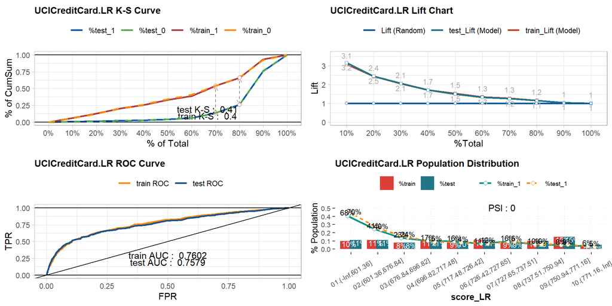

```
## -- Saving LR.params to:
## * C:\Users\HANSEN\AppData\Local\Temp\Rtmp02ToD9/UCICreditCard/performance/LR/LR.params.csv
```